```python
from IPython.display import HTML

HTML('''<script>
code_show=true;
function code_toggle() {
 if (code_show){
 $('div.input').hide();
 } else {
 $('div.input').show();
 }
 code_show = !code_show
}
$( document ).ready(code_toggle);
</script>''')
```

# Analysis Report for the WeRateDogs Project

## by Oluwasola Oyinloye

Date: September 01, 2022

### Introduction:

After having gathered, assessed and cleaned WeRateDogs twitter data I conducted some analysis on the dataset to establish some insights. The final twitter archives master dataset had features like favourite count, retweet count, tweet text, dog type, image url, prediction for the images, etc.

### Analysis and Visualization:

Out of all the features in the dataset the features of interest to me were source of the tweet, common dog names. I found out that most of the tweet were from the Iphone device which suggested that majority were iphone users, and also there seems to be common dogs names like Charlie, Oliver, Lucy, Cooper, Penny. In terms of dog types, floofers and puppos had higher average ratings as compared to doggos and puppers. Though this can also be attributed to the fact that the number of dogs classified as floofers and puppos was a lot less than the number of dogs classified as doggos and puppers.

#### Bar chart of most common dogs

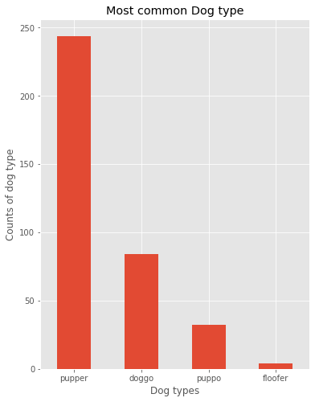

```python
import pandas as pd
import matplotlib.pyplot as plt
%matplotlib inline

# read the cleaned twitter archive files for analysis.
twitter = pd.read_csv('data/twitter_archive_master.csv')

# creating the bar plot
pd.value_counts(twitter.dog_type).plot.bar(rot=0, figsize=(6,8))
plt.xlabel("Dog types")
plt.ylabel("Counts of dog type")
plt.title("Most common Dog type")
plt.show();
```

There is a positive correlation between favorite (“like”) counts, and how much a post was retweeted. This correlation is important for the owner of the WeRateDogs twitter account to understand when determining method to increase users’ traffic on the page. A data analysis team could recommend previous posts with either a high retweet counts or high favorite count so that page owner could model future posts off historically popular posts.

#### Scatter plot of Favorite vs Retweet Counts

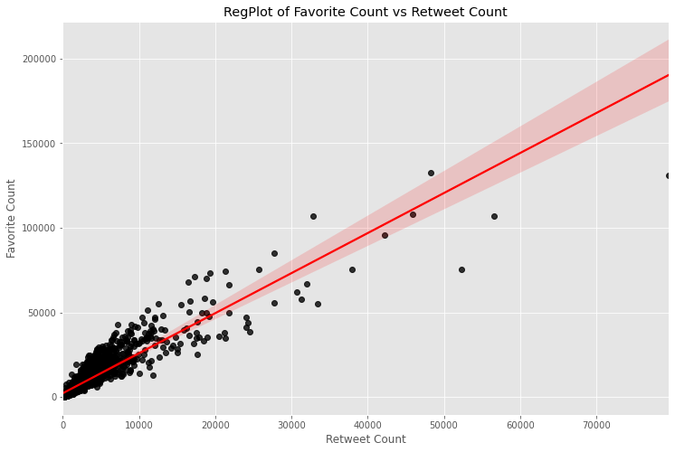

```python
import matplotlib
import matplotlib.pyplot as plt
plt.style.use('ggplot')
from matplotlib.pyplot import figure

%matplotlib inline
matplotlib.rcParams['figure.figsize'] = (12,8) # Adjust the comfiguretion of the plots we will create.

# Regplot with favorite count vs retweet count using seaborn.
favorite = twitter.favorite_count
retweet = twitter.retweet_count

sns.regplot(x=retweet, y=favorite, data=twitter, scatter_kws={'color':'black'}, line_kws={'color':'red'})
plt.title('RegPlot of Favorite Count vs Retweet Count')
plt.xlabel('Retweet Count')
plt.ylabel('Favorite Count');
```

### Conclusion:

The write up offers a straight look at the data wrangling process. There is so much more that can be done with this data set.